# Binary Searching

Pada algoritma **binary search** pencarian tidak dilakukan satu persatu, melainkan memanfaatkan kelebihan pencarian di data yang sudah terurut. Pada binary search, pencarian dilakukan pertama kali di indeks list yang berada ditengah. Jika data yang dicari sama dengan data pada indeks tersebut, maka pencarian berakhir. Akan tetapi jika data yang dicari lebih besar dari data yang berada di indeks tengah tersebuh, maka dilakukan pencarian lagi. Hanya saja pencarian tidak dilakukan pada seluruh data, hanya data yang berada indeks-indeks setelah indeks tengah tadi, karena data sebelum indeks tengah, pasti lebih kecil nilainya, sehingga tidak perlu dilakukan pencarian lagi. Proses ini dilakukan secara terus menerus sampai data ketemu atau tidak ada lagi data yang dapat dicari di dalam list. Oleh karena itu, binary search tidak perlu mencari di semua data pada list, sehingga waktu komputasi yang dibutuhkan lebih cepat dibandingkan dengan pencarian sequential search.

Ilustrasi pencarian binary search ini dapat dilihat pada Gambar berikut.

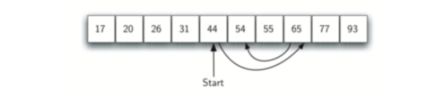

Pencarian Biner adalah algoritma pencarian efisien yang digunakan untuk menemukan elemen dalam **array yang sudah diurutkan** dengan membagi interval pencarian menjadi dua secara berulang. Algoritma ini mengurangi kompleksitas waktu menjadi O(log N), sehingga jauh lebih cepat daripada pencarian linier.

Berikut cara kerja Pencarian Biner

1. Temukan elemen tengah dari array tersebut.
2. Bandingkan elemen tengah dengan kunci target. Jika sama: kembalikan indeks.
3. Jika kuncinya lebih kecil: cari di bagian kiri.
4. Jika kuncinya lebih panjang: cari di bagian kanan.
5. Ulangi hingga elemen ditemukan atau ruang pencarian kosong.

```python
def binarySearch(listData, data):
    first = 0
    last = len(listData) - 1
    found = False
    while first <= last and not found:
        midpoint = (first + last) // 2
        if listData[midpoint] == data:
            found = True
        else:
            if data < listData[midpoint]:
                last = midpoint - 1
            else:
                first = midpoint + 1
    return found

a=[4,6,10,34,56,78,99]
print(binarySearch(a,34))
```

```
True
```

Modifikasi code Binary Search tersebut, sehingga return value dari fungsi tersebut adalah indeks data (jika data ada)

Selain dengan model iteratif, algoritma binary search juga dapat ditulis secara rekursif, seperti yang ditunjukkan pada program berikut

```python
def binarySearch2(listData, data):
    if len(listData) == 0:
        return False
    else:
        midpoint = len(listData) // 2
        if listData[midpoint] == data:
            return True
        else:
            if data < listData[midpoint]:
                return binarySearch2(listData[first:last+1], data)
            else:
                return binarySearch2(listData[midpoint + 1:], data)

a=[4,6,10,34,56,78,99]

binarySearch2(a,78)
```

```
True
```

[figure not shown]

### Pencarian Biner menggunakan bisect

Python menyediakan modul bisect , yang menawarkan fungsi bawaan untuk menjaga daftar tetap dalam urutan terurut dan melakukan pencarian biner yang efisien secara internal.

```python
import bisect

def binary_search_bisect(arr, x):
    i = bisect.bisect_left(arr, x)
    if i != len(arr) and arr[i] == x:
        return i
    else:
        return -1

arr = [2, 3, 4, 10, 40]
x = 10
result = binary_search_bisect(arr, x)

if result != -1:
    print("Element is present at index", result)
else:
    print("Element is not present in array")
```

```
Element is present at index 3
```

### Pencarian Biner Iteratif

Versi ini melakukan pencarian biner secara manual menggunakan perulangan while - efisien dalam hal waktu dan ruang.

```python
def binary_search(arr, x):
    low = 0
    high = len(arr) - 1

    while low <= high:
        mid = low + (high - low) // 2

        if arr[mid] < x:
            low = mid + 1
        elif arr[mid] > x:
            high = mid - 1
        else:
            return mid
    return -1

arr = [2, 3, 4, 10, 40]
x = 10
result = binary_search(arr, x)

if result != -1:
    print("Element is present at index", result)
else:
    print("Element is not present in array")
```

```
Element is present at index 3
```